# Road Accidents

Univariate Analysis

2022-05-05

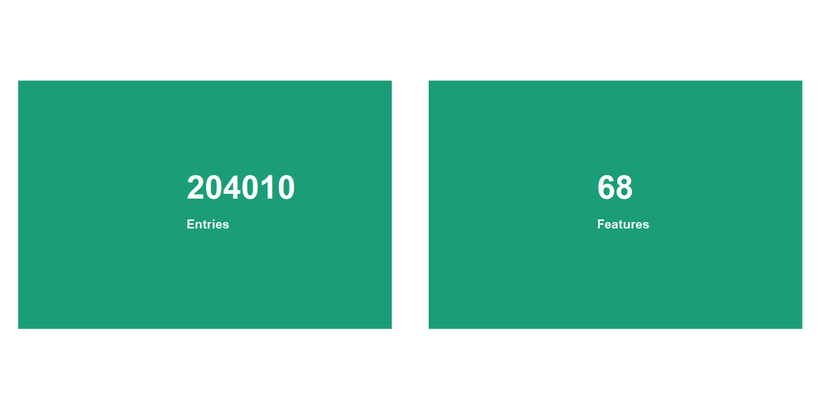

# Feature definitions and summaries

## 1. Time variables

**AN**: Year,  
**DT_ACCDN**: Date,  
**HR_ACCDN**: Hour,  
**JR_SEMN_ACCDN**: Day.

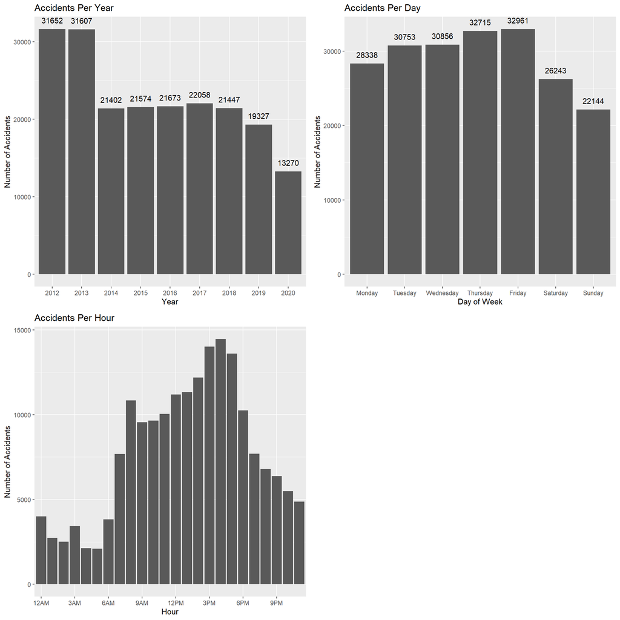

The percentage of null values for the hour of accidents is 8.45 %.

Unless mentioned, the variables do not have null values.

## 2. Losses and Damagaes (27 variables)

We will divide the 27 variables into 3 groups.  
**The first** group contains one variable: “Gravité: Severity”. It’s a categorical variable of 5 categories:

- Deadly: at least one victim died during the 30 days following the accident.
- Severe injuries: At least one victim was severely injured.
- Light injuries: One or more victims were lightly injured.
- Material damage only: Material damage with value exceeding $2000.
- Inferior material damage: Material damage with value equal to or below $2000.

*Whenever deaths are counted, deaths happening during the 30 days following the accident are included*

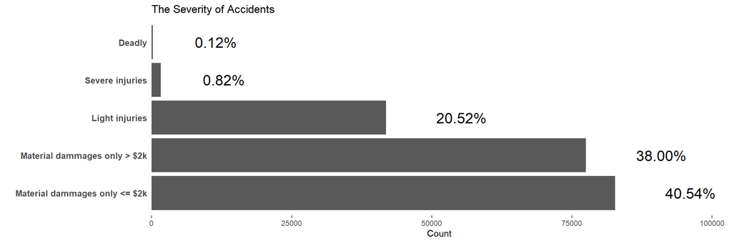

**The second** group breaks down the injuries. We have the following groups:

- NB_VICTIMES_TOTAL: Total number of victims
  - NB_MORTS: Number of dead victims.
  - NB_BLESSES_GRAVES: Number of victims severely injured.
  - NB_BLESSES_LEGERS: Number of victims lightly injured.
- NB_VICTIMES_PIETON: Total number of pedestrian victims.
  - NB_DECES_PIETON: Number of dead pedestrians.
  - NB_BLESSES_PIETON: Number of injured pedestrians (severe or light).
- NB_VICTIMES_MOTO: Total number of motorcyclist victims.
  - NB_DECES_MOTO: Number of dead motorcyclists.
  - NB_BLESSES_MOTO: Number of injured motorcyclists.
- NB_VICTIMES_VELO: Number of cyclist victims.
  - NB_DECES_VELO: Number of dead cyclists.
  - NB_BLESSES_VELO: Number of injured cyclists

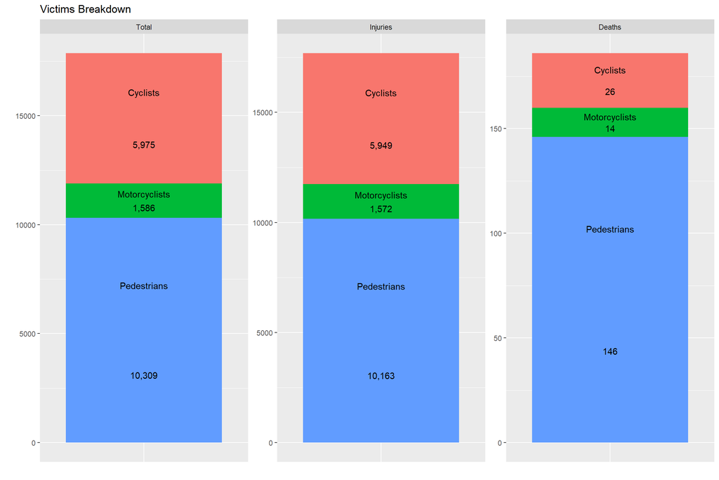

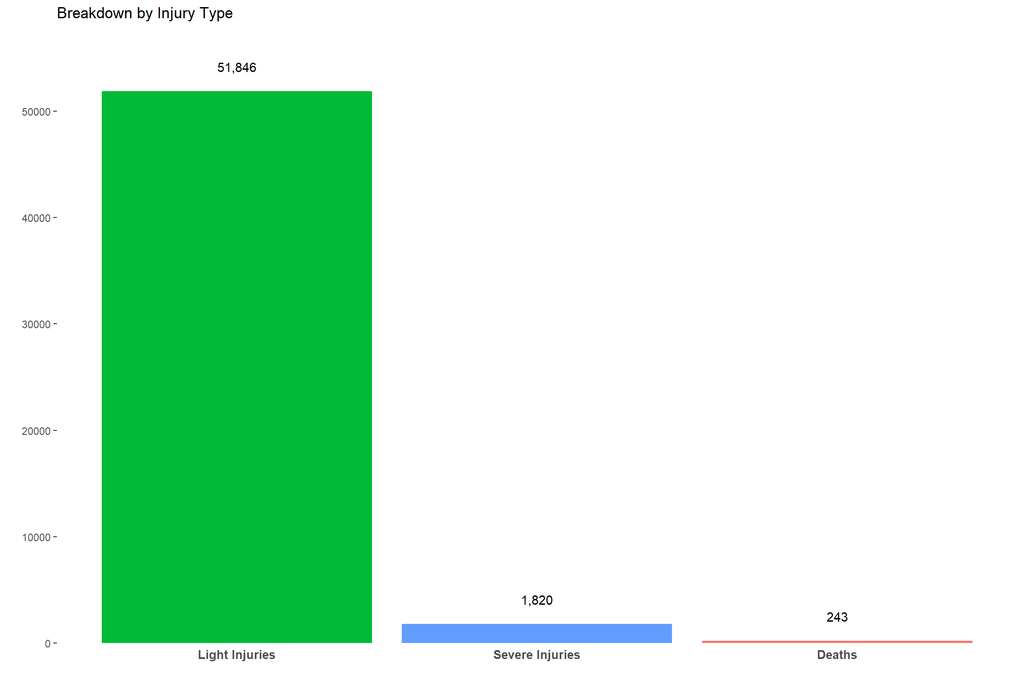

**The third** group breaks down the type of vehicles involved in the accident. As above, we have:

- NB_VEH_IMPLIQUES_ACCDN: Total number of vehicles involved.
  - nb_automobile_camion_leger: Number of automobiles and lightweight trucks.
  - nb_camionLourd_tractRoutier: Number of heavy trucks and tractors.
  - nb_outil_equipement: Number of Tool vehicles and equipment.
  - nb_tous_autobus_minibus: Number of buses, school buses and minibuses
  - nb_bicyclette: Number of bicycles.
  - nb_cyclomoteur: Number of scooters.
  - nb_motocyclette: Number of motorcycles.
  - nb_taxi: Number of taxis.
  - nb_urgence: Number of emergency vehicle.
  - nb_motoneige: Number of snowmobiles.
  - nb_VHR: Number of dirt bikes.
  - nb_autres_types: Number of other types of vehicles.
  - nb_veh_non_precise: Number of vehicles with unknown type.

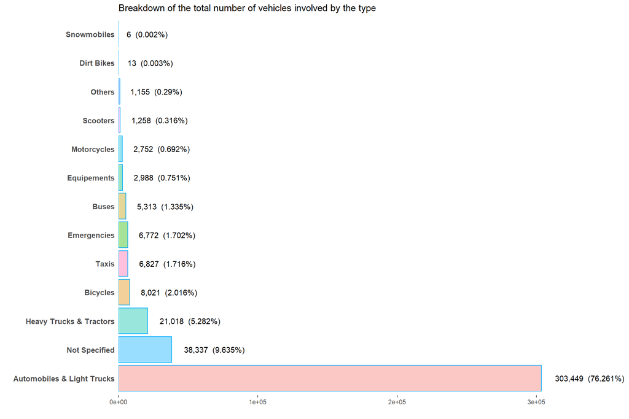

There are 3 rows with null values for all features above.

## 3. Accident nature

This group concerns the type of accidents and contains two variables:

- CD_GENRE_ACCDN: Type of accident. It has the following values
  - 31: Collision with a vehicle.
  - 32: Collision with a pedestrian.
  - 33: Collision with a cyclist.
  - 34: Collision with a train.
  - 35: Collision with a deer.
  - 36: Collision with a moose, bear, or a caribou.
  - 37: Collision with another animal.
  - 38: Collision with a temporary obstacle.
  - 39: Collision with a detached object (either from a vehicle or a construction).
  - 40: Collision with a street lamp.
  - 41: Collision with a traffic light.
  - 42: Collision with a public pole.
  - 43: Collision with a tree.
  - 44: Collision with a guardrail.
  - ….
  - ….
  - ….
  - : Not specified (4.9% of the data).
- CD_SIT_PRTCE_ACCDN: Describes a particular situation for when an accident happens. Mostly null values (97.7%).
  - 1: Spill.
  - 2: Load loss.
  - 3: Snow removal car is involved.
  - 9: Other particular situation causing the accident.
  - : Not specified. (97.7%)

## 4. Location variables

**Finally**, we look at the location and street conditions. There are 25 features, however, we have chosen a relevant subset.

- VITESSE_AUTOR: Authorized speed in KM/H. (39.4% not specified).

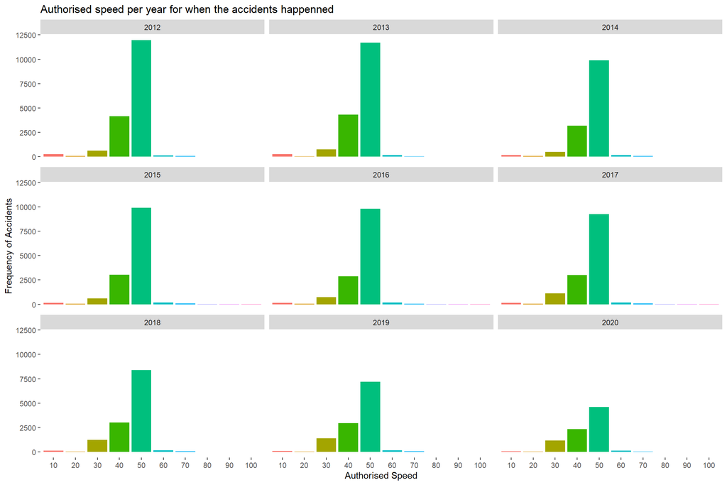

- CD_ETAT_SURF: Surface condition:
  - 11: Dry (No spill)
  - 12: Wet
  - 13: Water accumulation
  - 14: Sand or gravel
  - 15: Slush
  - 16: Snow
  - 17: Hard snow
  - 18: Ice
  - 19: Muddy
  - 20: Oily
  - 99: Other (0.3%)
  - : Not specified (6.0%)

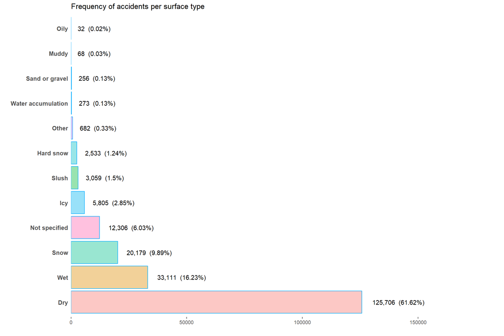

- CD_ECLRM: Lightning at the moment of the accident:
  - 1: Day and clear
  - 2: Day and semi-dark
  - 3: Night and lighted
  - 4: Night and dark
  - : Not specified (6.1%)

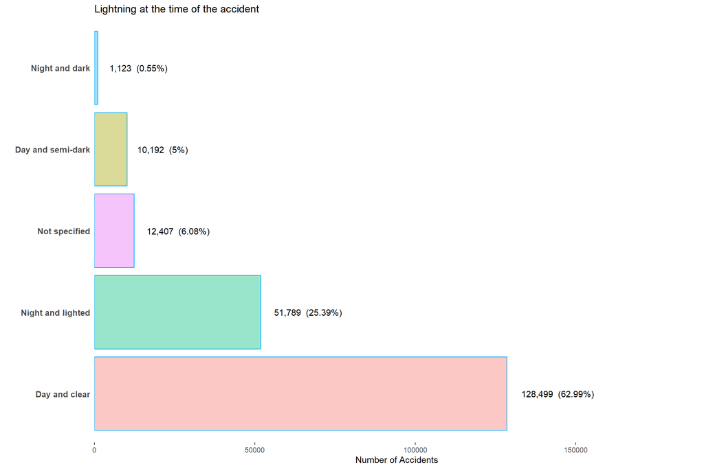

- CD_ENVRN_ACCDN: Environment (The dominant activity of the sector where the accident happenned):
  - 1: School area
  - 2: Residential
  - 3: Commercial
  - 4: Industrial
  - 5: Rural
  - 6: Forest
  - 7: Park
  - 9: Other (example: lakes)
  - : Not specified (3.3%)

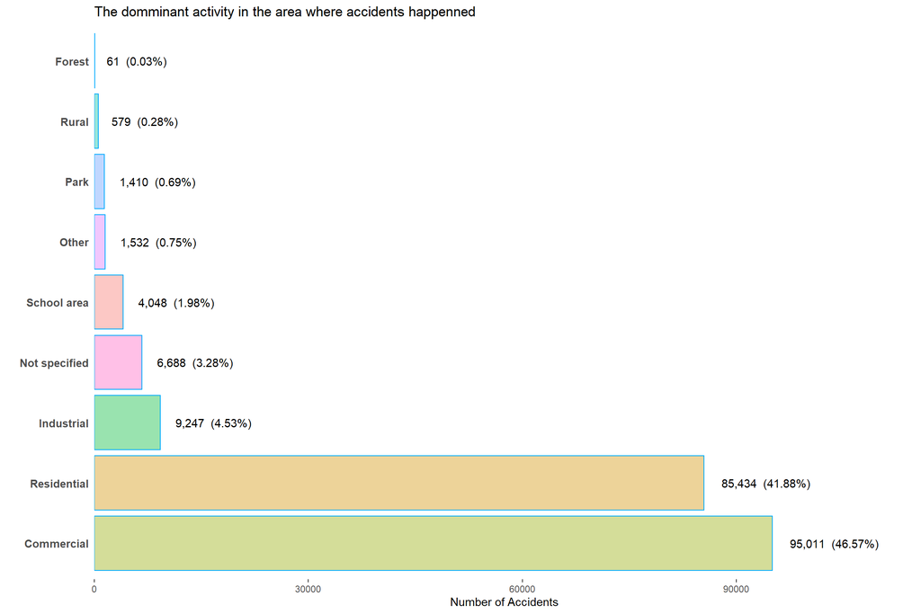

- CD_ETAT_CHASS: The quality of the road:
  - 1: In a good condition
  - 2: Under construction / repair
  - 3: Ruts (Deformation of the asphalt)
  - 4: Significant cracks
  - 5: Potholes
  - 6: Slopes and different leveling.
  - 9: Other (0.1%)
  - 0: Not specified. (76.0%)

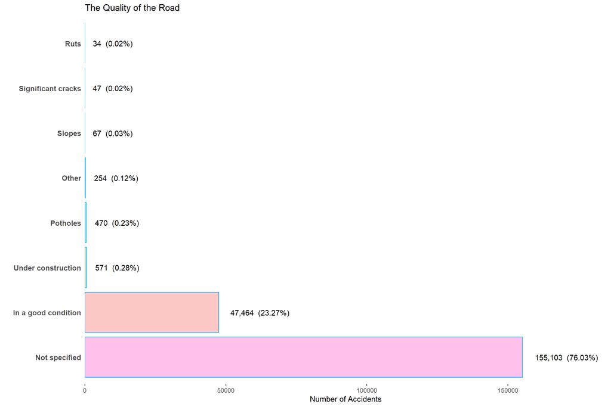

- CD_COND_METEO: Weather conditions:
  - 11: Clear sky
  - 12: Cloudy
  - 13: Foggy
  - 14: Drizzle
  - 15: Heavy rain
  - 16: Strong wind (no blowing snow or rain)
  - 17: Snow / hail
  - 18: Snowstorms and blowing snow
  - 19: Black ice
  - 99: Other (0.6%)
  - : Not specified (6.4%)

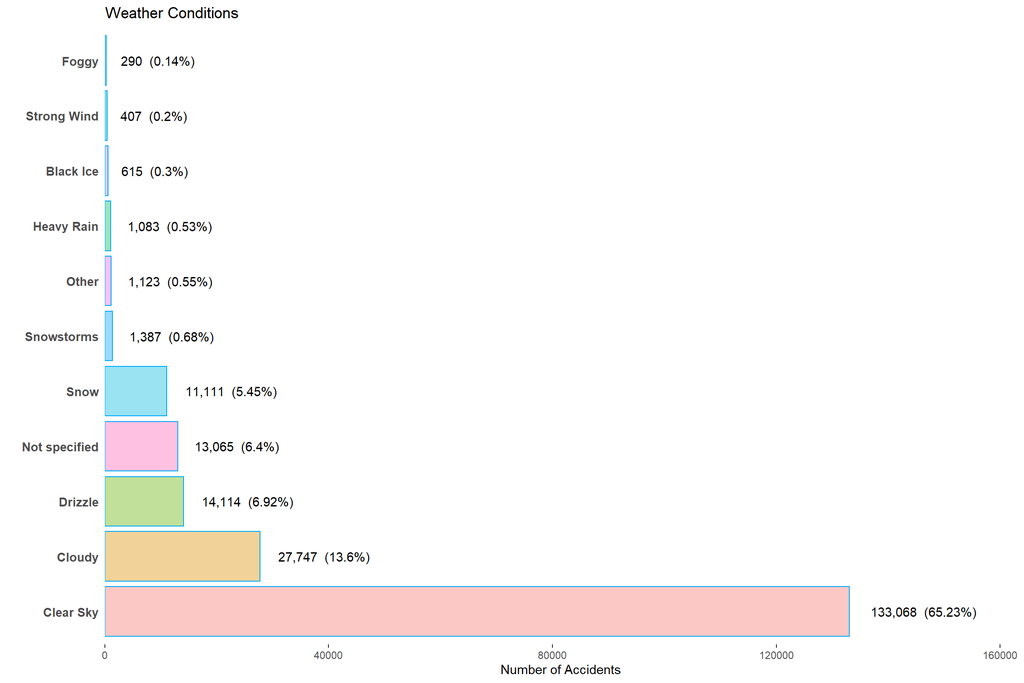